# Project: No-Show Appointment Analysis

- Introduction
- Data Wrangling
- Exploratory Data Analysis
- Conclusions

## Introduction

### Dataset Overview

- Contains information from 100k medical appointment reports in Brazil.
- Focuses on determining whether patients showed up for their scheduled appointments.
- Provides insights into patient characteristics, scheduled and actual appointment dates, and health-related factors.

### Dataset Fields

- **PatientId:** Unique identifier for each patient
- **AppointmentID:** Unique identifier for each appointment
- **Gender:** Gender of the patient (Male or Female)
- **ScheduledDay:** Date when the appointment was scheduled
- **AppointmentDay:** Date of the actual appointment
- **Age:** Age of the patient
- **Neighbourhood:** Location of the hospital
- **Scholarship:** Indicates whether the patient is enrolled in the Brazilian welfare program Bolsa Família (1 for enrolled, 0 for not enrolled)
- **Hipertension:** Indicates if the patient has hypertension (1 for yes, 0 for no)
- **Diabetes:** Indicates if the patient has diabetes (1 for yes, 0 for no)
- **Alcoholism:** Indicates if the patient has alcoholism (1 for yes, 0 for no)
- **Handcap:** Indicates if the patient has a handicap condition (1 for yes, 0 for no)
- **SMS_received:** Indicates if an SMS reminder was received by the patient (1 for yes, 0 for no)
- **No-show:** Indicates whether the patient showed up for the appointment ('No' for showed up, 'Yes' for did not show up)

### Research Questions

- **Does age influence the likelihood of missing an appointment?**
- **Do patients enrolled in the Bolsa Família welfare program (The scholarship) show up more or less frequently for appointments compared to those who are not enrolled?**

## Data Wrangling & Cleansing

```python
import pandas as pd
import numpy as np
import matplotlib.pyplot as plt
import seaborn as sns
%matplotlib inline
```

```python
df = pd.read_csv('noshow_data.csv')
```

```python
df.head(10) #Checking the raw data
```

|  | PatientId | AppointmentID | Gender | ScheduledDay | AppointmentDay | Age | Neighbourhood | Scholarship | Hipertension | Diabetes | Alcoholism | Handcap | SMS_received | No-show |
| --- | --- | --- | --- | --- | --- | --- | --- | --- | --- | --- | --- | --- | --- | --- |
| 0 | 2.987250e+13 | 5642903 | F | 2016-04-29T18:38:08Z | 2016-04-29T00:00:00Z | 62 | JARDIM DA PENHA | 0 | 1 | 0 | 0 | 0 | 0 | No |
| 1 | 5.589978e+14 | 5642503 | M | 2016-04-29T16:08:27Z | 2016-04-29T00:00:00Z | 56 | JARDIM DA PENHA | 0 | 0 | 0 | 0 | 0 | 0 | No |
| 2 | 4.262962e+12 | 5642549 | F | 2016-04-29T16:19:04Z | 2016-04-29T00:00:00Z | 62 | MATA DA PRAIA | 0 | 0 | 0 | 0 | 0 | 0 | No |
| 3 | 8.679512e+11 | 5642828 | F | 2016-04-29T17:29:31Z | 2016-04-29T00:00:00Z | 8 | PONTAL DE CAMBURI | 0 | 0 | 0 | 0 | 0 | 0 | No |
| 4 | 8.841186e+12 | 5642494 | F | 2016-04-29T16:07:23Z | 2016-04-29T00:00:00Z | 56 | JARDIM DA PENHA | 0 | 1 | 1 | 0 | 0 | 0 | No |
| 5 | 9.598513e+13 | 5626772 | F | 2016-04-27T08:36:51Z | 2016-04-29T00:00:00Z | 76 | REPÚBLICA | 0 | 1 | 0 | 0 | 0 | 0 | No |
| 6 | 7.336882e+14 | 5630279 | F | 2016-04-27T15:05:12Z | 2016-04-29T00:00:00Z | 23 | GOIABEIRAS | 0 | 0 | 0 | 0 | 0 | 0 | Yes |
| 7 | 3.449833e+12 | 5630575 | F | 2016-04-27T15:39:58Z | 2016-04-29T00:00:00Z | 39 | GOIABEIRAS | 0 | 0 | 0 | 0 | 0 | 0 | Yes |
| 8 | 5.639473e+13 | 5638447 | F | 2016-04-29T08:02:16Z | 2016-04-29T00:00:00Z | 21 | ANDORINHAS | 0 | 0 | 0 | 0 | 0 | 0 | No |
| 9 | 7.812456e+13 | 5629123 | F | 2016-04-27T12:48:25Z | 2016-04-29T00:00:00Z | 19 | CONQUISTA | 0 | 0 | 0 | 0 | 0 | 0 | No |

```python
df.shape
```

```
(110527, 14)
```

```python
df["PatientId"].duplicated().sum()
```

```
48228
```

```python
df["PatientId"].nunique()
```

```
62299
```

> There are a total of 62,299 unique values out of 110,527 for the patient id records. This suggests that some patients have multiple appointments.

```python
df.info() # Checking if there are any null values or incorrect data types
```

```
<class 'pandas.core.frame.DataFrame'>
RangeIndex: 110527 entries, 0 to 110526
Data columns (total 14 columns):
 #   Column          Non-Null Count   Dtype
---  ------          --------------   -----
 0   PatientId       110527 non-null  float64
 1   AppointmentID   110527 non-null  int64
 2   Gender          110527 non-null  object
 3   ScheduledDay    110527 non-null  object
 4   AppointmentDay  110527 non-null  object
 5   Age             110527 non-null  int64
 6   Neighbourhood   110527 non-null  object
 7   Scholarship     110527 non-null  int64
 8   Hipertension    110527 non-null  int64
 9   Diabetes        110527 non-null  int64
 10  Alcoholism      110527 non-null  int64
 11  Handcap         110527 non-null  int64
 12  SMS_received    110527 non-null  int64
 13  No-show         110527 non-null  object
dtypes: float64(1), int64(8), object(5)
memory usage: 11.8+ MB
```

```python
df.describe() #Checking the descriptive stats of the data
```

|  | PatientId | AppointmentID | Age | Scholarship | Hipertension | Diabetes | Alcoholism | Handcap | SMS_received |
| --- | --- | --- | --- | --- | --- | --- | --- | --- | --- |
| count | 1.105270e+05 | 1.105270e+05 | 110527.000000 | 110527.000000 | 110527.000000 | 110527.000000 | 110527.000000 | 110527.000000 | 110527.000000 |
| mean | 1.474963e+14 | 5.675305e+06 | 37.088874 | 0.098266 | 0.197246 | 0.071865 | 0.030400 | 0.022248 | 0.321026 |
| std | 2.560949e+14 | 7.129575e+04 | 23.110205 | 0.297675 | 0.397921 | 0.258265 | 0.171686 | 0.161543 | 0.466873 |
| min | 3.921784e+04 | 5.030230e+06 | -1.000000 | 0.000000 | 0.000000 | 0.000000 | 0.000000 | 0.000000 | 0.000000 |
| 25% | 4.172614e+12 | 5.640286e+06 | 18.000000 | 0.000000 | 0.000000 | 0.000000 | 0.000000 | 0.000000 | 0.000000 |
| 50% | 3.173184e+13 | 5.680573e+06 | 37.000000 | 0.000000 | 0.000000 | 0.000000 | 0.000000 | 0.000000 | 0.000000 |
| 75% | 9.439172e+13 | 5.725524e+06 | 55.000000 | 0.000000 | 0.000000 | 0.000000 | 0.000000 | 0.000000 | 1.000000 |
| max | 9.999816e+14 | 5.790484e+06 | 115.000000 | 1.000000 | 1.000000 | 1.000000 | 1.000000 | 4.000000 | 1.000000 |

> The min age is -1 which should not be valid, and i will change the format of the date and time

```python
df[df['Age']<0]
```

|  | PatientId | AppointmentID | Gender | ScheduledDay | AppointmentDay | Age | Neighbourhood | Scholarship | Hipertension | Diabetes | Alcoholism | Handcap | SMS_received | No-show |
| --- | --- | --- | --- | --- | --- | --- | --- | --- | --- | --- | --- | --- | --- | --- |
| 99832 | 4.659432e+14 | 5775010 | F | 2016-06-06T08:58:13Z | 2016-06-06T00:00:00Z | -1 | ROMÃO | 0 | 0 | 0 | 0 | 0 | 0 | No |

```python
df.drop(index=99832,inplace=True) # Removing the wrongly inputted age
```

```python
#Changing the data type
df['ScheduledDay'] = pd.to_datetime(df['ScheduledDay'])
df['AppointmentDay'] = pd.to_datetime(df['AppointmentDay'])
```

```python
df.describe()
```

|  | PatientId | AppointmentID | Age | Scholarship | Hipertension | Diabetes | Alcoholism | Handcap | SMS_received |
| --- | --- | --- | --- | --- | --- | --- | --- | --- | --- |
| count | 1.105260e+05 | 1.105260e+05 | 110526.000000 | 110526.000000 | 110526.000000 | 110526.000000 | 110526.000000 | 110526.000000 | 110526.000000 |
| mean | 1.474934e+14 | 5.675304e+06 | 37.089219 | 0.098266 | 0.197248 | 0.071865 | 0.030400 | 0.022248 | 0.321029 |
| std | 2.560943e+14 | 7.129544e+04 | 23.110026 | 0.297676 | 0.397923 | 0.258266 | 0.171686 | 0.161543 | 0.466874 |
| min | 3.921784e+04 | 5.030230e+06 | 0.000000 | 0.000000 | 0.000000 | 0.000000 | 0.000000 | 0.000000 | 0.000000 |
| 25% | 4.172536e+12 | 5.640285e+06 | 18.000000 | 0.000000 | 0.000000 | 0.000000 | 0.000000 | 0.000000 | 0.000000 |
| 50% | 3.173184e+13 | 5.680572e+06 | 37.000000 | 0.000000 | 0.000000 | 0.000000 | 0.000000 | 0.000000 | 0.000000 |
| 75% | 9.438963e+13 | 5.725523e+06 | 55.000000 | 0.000000 | 0.000000 | 0.000000 | 0.000000 | 0.000000 | 1.000000 |
| max | 9.999816e+14 | 5.790484e+06 | 115.000000 | 1.000000 | 1.000000 | 1.000000 | 1.000000 | 4.000000 | 1.000000 |

```python
df.info()
```

```
<class 'pandas.core.frame.DataFrame'>
Index: 110526 entries, 0 to 110526
Data columns (total 14 columns):
 #   Column          Non-Null Count   Dtype
---  ------          --------------   -----
 0   PatientId       110526 non-null  float64
 1   AppointmentID   110526 non-null  int64
 2   Gender          110526 non-null  object
 3   ScheduledDay    110526 non-null  datetime64[ns, UTC]
 4   AppointmentDay  110526 non-null  datetime64[ns, UTC]
 5   Age             110526 non-null  int64
 6   Neighbourhood   110526 non-null  object
 7   Scholarship     110526 non-null  int64
 8   Hipertension    110526 non-null  int64
 9   Diabetes        110526 non-null  int64
 10  Alcoholism      110526 non-null  int64
 11  Handcap         110526 non-null  int64
 12  SMS_received    110526 non-null  int64
 13  No-show         110526 non-null  object
dtypes: datetime64[ns, UTC](2), float64(1), int64(8), object(3)
memory usage: 12.6+ MB
```

> Give my research questions stated above, there are columns i believe i will not need to further do my analysis such as (PatientId, AppointmentID, Neighbourhood, Gender, Hipertension, Diabetes, Alcoholism, Handcap) so i will drop them to make it easier for myself

```python
df.drop(['PatientId', 'AppointmentID','Neighbourhood','Gender', 'Hipertension','Diabetes','Alcoholism','Handcap'], axis=1, inplace=True)
```

```python
df.head() # Checking the remaining cols
```

|  | ScheduledDay | AppointmentDay | Age | Scholarship | SMS_received | No-show |
| --- | --- | --- | --- | --- | --- | --- |
| 0 | 2016-04-29 18:38:08+00:00 | 2016-04-29 00:00:00+00:00 | 62 | 0 | 0 | No |
| 1 | 2016-04-29 16:08:27+00:00 | 2016-04-29 00:00:00+00:00 | 56 | 0 | 0 | No |
| 2 | 2016-04-29 16:19:04+00:00 | 2016-04-29 00:00:00+00:00 | 62 | 0 | 0 | No |
| 3 | 2016-04-29 17:29:31+00:00 | 2016-04-29 00:00:00+00:00 | 8 | 0 | 0 | No |
| 4 | 2016-04-29 16:07:23+00:00 | 2016-04-29 00:00:00+00:00 | 56 | 0 | 0 | No |

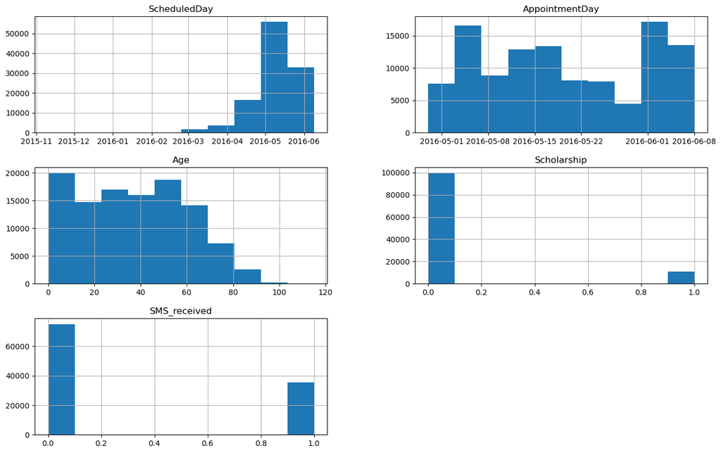

```python
df.hist(figsize=(16,10)); #Viewing the distribution of the data
```

```python
df.info()
```

```
<class 'pandas.core.frame.DataFrame'>
Index: 110526 entries, 0 to 110526
Data columns (total 6 columns):
 #   Column          Non-Null Count   Dtype
---  ------          --------------   -----
 0   ScheduledDay    110526 non-null  datetime64[ns, UTC]
 1   AppointmentDay  110526 non-null  datetime64[ns, UTC]
 2   Age             110526 non-null  int64
 3   Scholarship     110526 non-null  int64
 4   SMS_received    110526 non-null  int64
 5   No-show         110526 non-null  object
dtypes: datetime64[ns, UTC](2), int64(3), object(1)
memory usage: 5.9+ MB
```

## Exploratory Data Analysis

> I beilieve the data is ready to go now for the analysis

### Research Question 1: Does age influence the likelihood of missing an appointment?

#### I will first check that the data is ready to be analyzed and plotted

```python
df['No-show'] = df['No-show'].map({'No': 0, 'Yes': 1}) # Changing the string in no show to integer to make it plottable
```

```python
df.info()
```

```
<class 'pandas.core.frame.DataFrame'>
Index: 110526 entries, 0 to 110526
Data columns (total 6 columns):
 #   Column          Non-Null Count   Dtype
---  ------          --------------   -----
 0   ScheduledDay    110526 non-null  datetime64[ns, UTC]
 1   AppointmentDay  110526 non-null  datetime64[ns, UTC]
 2   Age             110526 non-null  int64
 3   Scholarship     110526 non-null  int64
 4   SMS_received    110526 non-null  int64
 5   No-show         110526 non-null  int64
dtypes: datetime64[ns, UTC](2), int64(4)
memory usage: 5.9 MB
```

```python
G_age = df.groupby('Age')['No-show'].mean().reset_index()
#What this line does:
#Creating a new sub-dataframe that groups the dataset according to 'Age' and calculates the mean of the 'No-Show'
#The reset_index() creates a new indexing column, instead of taking Age aas the index column
```

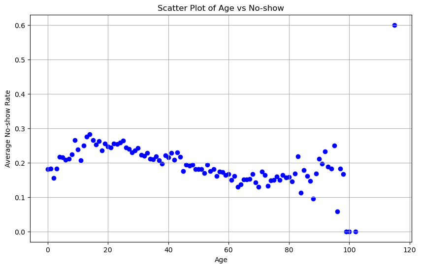

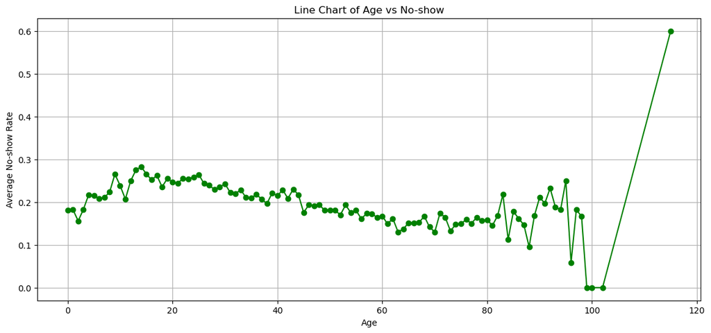

```python
#Scatter
plt.figure(figsize=(10,6))
plt.scatter(G_age['Age'], G_age['No-show'], color='blue')
plt.title('Scatter Plot of Age vs No-show')
plt.xlabel('Age')
plt.ylabel('Average No-show Rate')
plt.grid(True)
plt.show()

#Line
plt.figure(figsize=(14,6))
plt.plot(G_age['Age'], G_age['No-show'], marker='o', linestyle='-', color='green')
plt.title('Line Chart of Age vs No-show')
plt.xlabel('Age')
plt.ylabel('Average No-show Rate')
plt.grid(True)
plt.show()
```

These two graphs show an outlier, so i will remove it to get a better view

```python
G_age.describe()
```

|  | Age | No-show |
| --- | --- | --- |
| count | 103.000000 | 103.000000 |
| mean | 51.135922 | 0.192724 |
| std | 30.137934 | 0.067037 |
| min | 0.000000 | 0.000000 |
| 25% | 25.500000 | 0.161562 |
| 50% | 51.000000 | 0.188679 |
| 75% | 76.500000 | 0.228586 |
| max | 115.000000 | 0.600000 |

```python
G_age[G_age['Age']>114]
```

|  | Age | No-show |
| --- | --- | --- |
| 102 | 115 | 0.6 |

```python
G_age.drop(index=102,inplace=True)
```

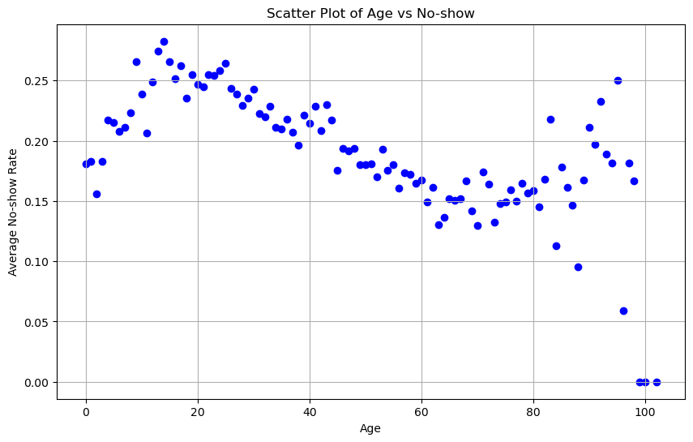

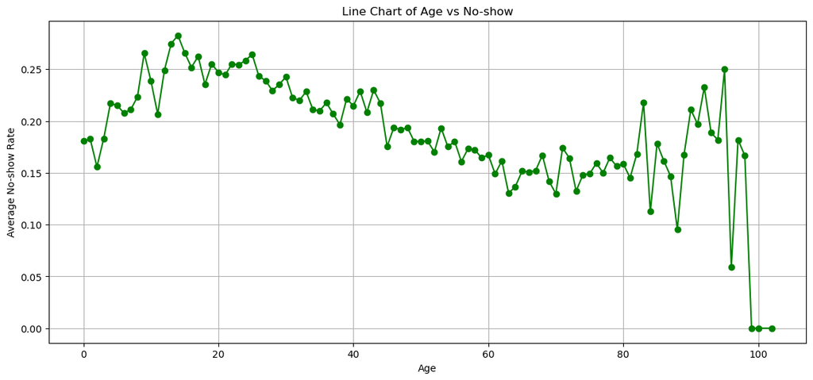

```python
#Scatter
plt.figure(figsize=(10,6))
plt.scatter(G_age['Age'], G_age['No-show'], color='blue')
plt.title('Scatter Plot of Age vs No-show')
plt.xlabel('Age')
plt.ylabel('Average No-show Rate')
plt.grid(True)
plt.show()

#Line
plt.figure(figsize=(14,6))
plt.plot(G_age['Age'], G_age['No-show'], marker='o', linestyle='-', color='green')
plt.title('Line Chart of Age vs No-show')
plt.xlabel('Age')
plt.ylabel('Average No-show Rate')
plt.grid(True)
plt.show()
```

## Conclusion

> Limitation: One limitation that crossed my mind during limitation is that for these results, I solely focused on the relationship between age and the appointment attendance, without considering the other potential factors that can affect people along with age. Such as the health conditions, if they recieved the SMS of the appointment, etc..

### Research Question 2: Do patients enrolled in the Bolsa Família welfare program show up more or less frequently for appointments compared to those who are not enrolled?

> To answer this question, i will first make two new subcolumns of data one stating that the patients are enrolled and the other not. Then using these two coloumns, i will calculate the average show/no-show which will show us which group (Scholorships or not) have the higher average of attending their appointments

```python
Scholarship_yes = df[df['Scholarship'] == 1] #Filtering the DataFrame to include only rows where 'Scholarship' column is 1
Scholarship_no = df[df['Scholarship'] == 0] #Filtering the DataFrame to include only rows where 'Scholarship' column is 0
```

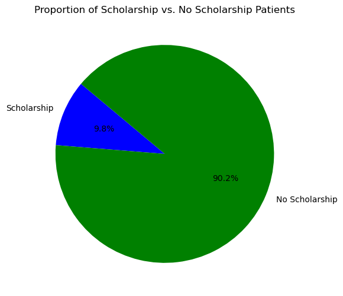

```python
sizes = [len(Scholarship_yes), len(Scholarship_no)]
labels = ['Scholarship', 'No Scholarship']
colors = ['blue', 'green']
plt.figure(figsize=(8,6))
plt.pie(sizes, labels=labels, colors=colors, autopct='%1.1f%%', startangle=140)
plt.title('Proportion of Scholarship vs. No Scholarship Patients')
plt.show()
```

The Majority of the patients do not have a scholarship

```python
import matplotlib.pyplot as plt

def plot_attendance_by_group(data, group_column, group_labels):
    """
        This function  plots a bar chart and prints the average 'No-show' rate for any group
        in the DataFrame by specifying the group column and labels
        It takes in 3 arguments:
            - The dataset
            - The group column
            - The group Labels to put on the bar chart
    """
    #Calculating average 'No-show' rate
    avg_no_show = data.groupby(group_column)['No-show'].mean() * 100

    #Counting the number of patients who attended and missed appointments
    attended = data[data['No-show'] == 0].groupby(group_column)['No-show'].count()
    missed = data[data['No-show'] == 1].groupby(group_column)['No-show'].count()

    #Bar chart
    x = range(len(group_labels))

    plt.figure(figsize=(10, 6))
    plt.bar(x, attended, color='blue', label='Attended')
    plt.bar(x, missed, bottom=attended, color='red', label='Missed')

    plt.xlabel(group_column)
    plt.ylabel('Number of Patients')
    plt.title(f'Number of Patients by {group_column} and Attendance')
    plt.xticks(x, group_labels)
    plt.legend()
    plt.show()

    #Printing the average 'No-show' rate
    for label, rate in avg_no_show.items():
        if label == 0:
            label = "No"
            print(f"{label}: {round(rate, 2)}%")
        elif label == 1:
            label = "Yes"
            print(f"{label}: {round(rate, 2)}%")
        else:
            print(f"{label}: {round(rate, 2)}%")
```

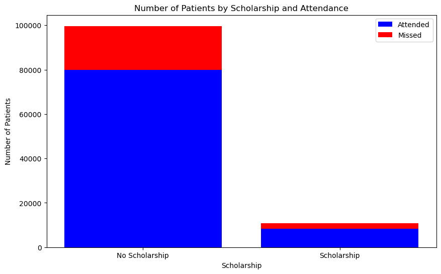

```
No: 19.81%
Yes: 23.74%
```

```python
plot_attendance_by_group(df, 'Scholarship', ['No Scholarship', 'Scholarship']) # Using the created function for the Scholarship column Along with the mean
```

As can be seen by the stacked bar chart, the patients who do not have a scholarship attended alot more than the patients who have a scholarship, and the average mean percentage of the attendees is higher.

> *This function can be used in other scenarios, I have tested it with the 'SMS_received' column and it shows the results. However, I did not display nor run it as it is not relavant to the current analysis*

[figure not shown]

```python
attended_Scholar = len(Scholarship_yes[Scholarship_yes['No-show'] == 0])
missed_Scholar = len(Scholarship_yes[Scholarship_yes['No-show'] == 1])

values = [attended_Scholar, missed_Scholar]

plt.figure(figsize=(8, 6))
plt.bar(labels, values, color=['green', 'red'])
plt.xlabel('Attendance Status')
plt.ylabel('Number of Patients')
plt.title('Number of Patients with Scholarship by Attendance Status')
plt.show()
```

There is a higher number of patients who have the scholarship and attended

## Conclusion

> Limitation: This is the same case as Q1, the accuracy can be affected if the reasons behind the missed appointments. The scholarship could be a proxy for other socioeconomic factors that were not accounted for in this study, which can affect the accuracy greatly. Another limitation i believe is that the rate of the patients who have recieved a scholarship if far less that the patients who have not, making the raw data less in quantity, which in my experience usually affects the accuracy of the analysis